# Generate Repeated Measures Data

# Disclaimer

Data with repeated measurements are described.

# Single Observation Data

The data with single observations for body weight and breast circumference from chapter 2 of the lecture notes are used as basis

Breast Circumference and Body Weight for 10 Animals

| Animal | Breast Circumference | Body Weight |
| --- | --- | --- |
| 1 | 176 | 471 |
| 2 | 177 | 463 |
| 3 | 178 | 481 |
| 4 | 179 | 470 |
| 5 | 179 | 496 |
| 6 | 180 | 491 |
| 7 | 181 | 518 |
| 8 | 182 | 511 |
| 9 | 183 | 510 |
| 10 | 184 | 541 |

# Generate Multiple Observations per Animal

For course notes, we choose 4 animals and generate 3 repetitions from each observation. The variation within the observations for body weight of one animal is 25% of the total phenotypic variation for body weight. For breast circumference the within-animal variation is 4% of the total phenotypic variance of breast circumference.

```r
set.seed(432)
vec_sel_ani <- sample(tbl_reg$Animal, size = n_nr_ani)
vec_sel_ani[1] <- 2
# loop over selected animals
tbl_rep_obs <- NULL
for (aidx in vec_sel_ani){
  # add observation of currently selected animal aidx
  if (is.null(tbl_rep_obs)){
    tbl_rep_obs <- tbl_reg[aidx,]
  } else {
    tbl_rep_obs <- dplyr::bind_rows(tbl_rep_obs, tbl_reg[aidx,])
  }
  # add repeated observations
  tbl_rep_cur <- tibble::tibble(Animal = rep(aidx, n_nr_rep-1),
                                `Breast Circumference` = rnorm((n_nr_rep-1),
                                                               mean = tbl_reg$`Breast Circumference`[aidx],
                                                               sd = n_sd_bc*n_sd_ratio_bc),
                                `Body Weight` = rnorm((n_nr_rep-1),
                                                      mean = tbl_reg$`Body Weight`[aidx],
                                                      sd = n_sd_bw*n_sd_ratio_bw))
  tbl_rep_obs <- dplyr::bind_rows(tbl_rep_obs, tbl_rep_cur)

}
tbl_rep_obs
```

| Animal | Breast Circumference | Body Weight |
| --- | --- | --- |
| 2 | 177.0000 | 463.0000 |
| 2 | 177.3129 | 468.8940 |
| 2 | 177.3292 | 467.8753 |
| 5 | 179.0000 | 496.0000 |
| 5 | 178.6501 | 495.0033 |
| 5 | 178.7485 | 493.6563 |
| 7 | 181.0000 | 518.0000 |
| 7 | 180.9819 | 509.3221 |
| 7 | 181.1467 | 506.5958 |
| 10 | 184.0000 | 541.0000 |

[output cut: 2 more lines]

# File

The generated data is written to a file.

```r
s_rep_obs_path <- file.path(here::here(), "docs", "data", "asm_bw_bc_rep_obs.csv")
if (!file.exists(s_rep_obs_path)) readr::write_csv(tbl_rep_obs, file = s_rep_obs_path)
```

# Data with Breed

```r
tbl_bw_bc_breed <- tibble::tibble(Animal = c(1:10),
                          `Breast Circumference` = c(176, 177, 178, 179, 179, 180, 181, 182,183, 184),
                          `Body Weight`          = c(471, 463, 481, 470, 496, 491, 518, 511, 510, 541),
                          Breed                  = c("Angus",
                                                     "Angus",
                                                     "Simmental",
                                                     "Angus",
                                                     "Simmental",
                                                     "Simmental",
                                                     "Limousin",
                                                     "Limousin",
                                                     "Limousin",
                                                     "Limousin"))
```

The selected animals are given by

```r
tbl_rep_obs$Animal
```

```
 [1]  2  2  2  5  5  5  7  7  7 10 10 10
```

The breed for those animals are obtained by

```r
tbl_bw_bc_breed$Breed[tbl_rep_obs$Animal]
```

```
 [1] "Angus"     "Angus"     "Angus"     "Simmental" "Simmental" "Simmental" "Limousin"  "Limousin"  "Limousin"  "Limousin"
[11] "Limousin"  "Limousin"
```

```r
tbl_rep_obs_breed <- dplyr::select(tbl_rep_obs, Animal, `Body Weight`)
tbl_rep_obs_breed$Breed <- tbl_bw_bc_breed$Breed[tbl_rep_obs$Animal]
tbl_rep_obs_breed$Time <- rep(english::ordinal(c(1:n_nr_rep)), n_nr_ani)
tbl_rep_obs_breed
```

| Animal | Body Weight | Breed | Time |
| --- | --- | --- | --- |
| 2 | 463.0000 | Angus | first |
| 2 | 468.8940 | Angus | second |
| 2 | 467.8753 | Angus | third |
| 5 | 496.0000 | Simmental | first |
| 5 | 495.0033 | Simmental | second |
| 5 | 493.6563 | Simmental | third |
| 7 | 518.0000 | Limousin | first |
| 7 | 509.3221 | Limousin | second |
| 7 | 506.5958 | Limousin | third |
| 10 | 541.0000 | Limousin | first |

[output cut: 2 more lines]

```r
s_bw_breed_rep_obs_path <- file.path(here::here(), "docs", "data", "asm_bw_breed_rep_obs.csv")
if (!file.exists(s_bw_breed_rep_obs_path)) readr::write_csv(tbl_rep_obs_breed, file = s_bw_breed_rep_obs_path)
```

# Plot

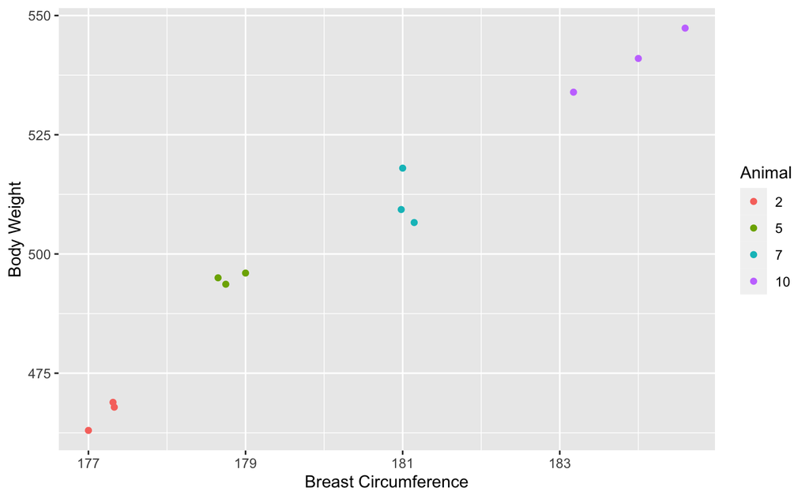

```r
tbl_rep_obs$Animal <- as.factor(tbl_rep_obs$Animal)
ggplot2::ggplot(data = tbl_rep_obs, mapping = ggplot2::aes(x = `Breast Circumference`,
                                                           y = `Body Weight`,
                                                           color = Animal)) +
  ggplot2::geom_point()
```

# Analysis

## Linear Regression

The repeated observation data can still be analysed with a linear regression model

```r
lm_rep_obs <- lm(`Body Weight` ~ `Breast Circumference`, data = tbl_rep_obs)
summary(lm_rep_obs)
```

```
Call:
lm(formula = `Body Weight` ~ `Breast Circumference`, data = tbl_rep_obs)

Residuals:
   Min     1Q Median     3Q    Max
-6.337 -4.024 -1.732  5.751  8.351

Coefficients:
                         Estimate Std. Error t value Pr(>|t|)
(Intercept)            -1387.8875   113.8217  -12.19 2.51e-07 ***
`Breast Circumference`    10.4928     0.6314   16.62 1.30e-08 ***
---
Signif. codes:  0 ‘***’ 0.001 ‘**’ 0.01 ‘*’ 0.05 ‘.’ 0.1 ‘ ’ 1

Residual standard error: 5.559 on 10 degrees of freedom
Multiple R-squared:  0.9651,    Adjusted R-squared:  0.9616
F-statistic: 276.2 on 1 and 10 DF,  p-value: 1.302e-08
```

But the assumptions of independent observations is violated. This can be seen in the residuals plot.

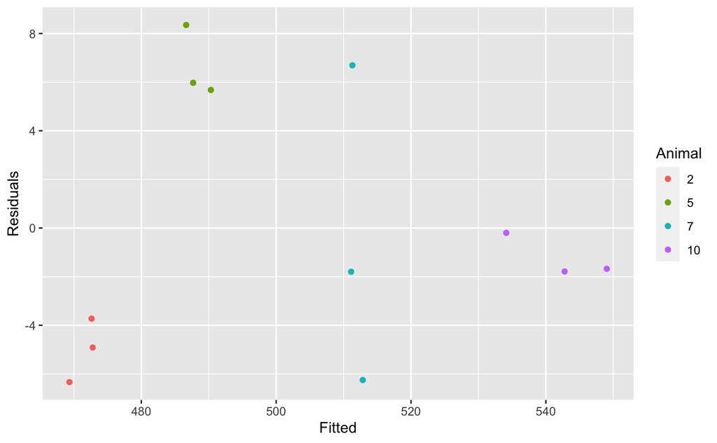

```r
tbl_rep_obs$Animal <- as.factor(tbl_rep_obs$Animal)
ggplot2::ggplot(data = tibble::tibble(Animal = tbl_rep_obs$Animal,
                                      Fitted = fitted(lm_rep_obs),
                                      Residuals = residuals(lm_rep_obs)),
                ggplot2::aes(x = Fitted, y = Residuals, color = Animal)) +
  ggplot2::geom_point()
```

Residuals vs Fitted Plot

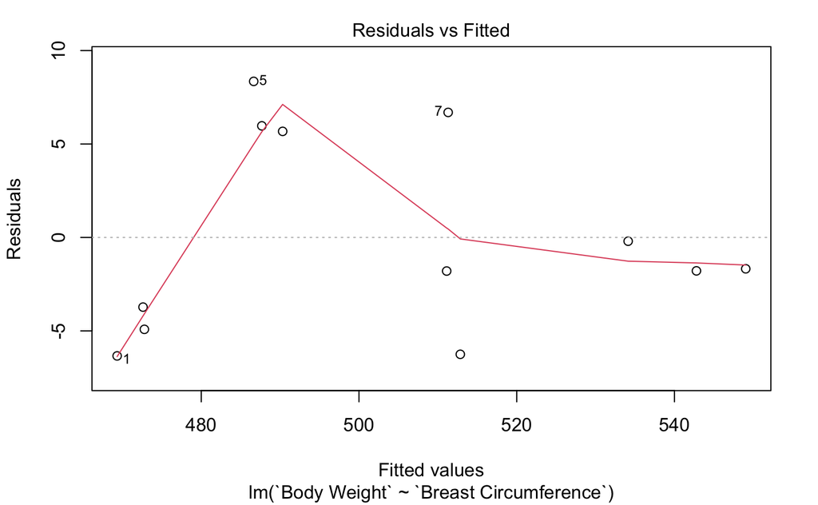

```r
plot(lm_rep_obs, 1)
```

QQ-Plot

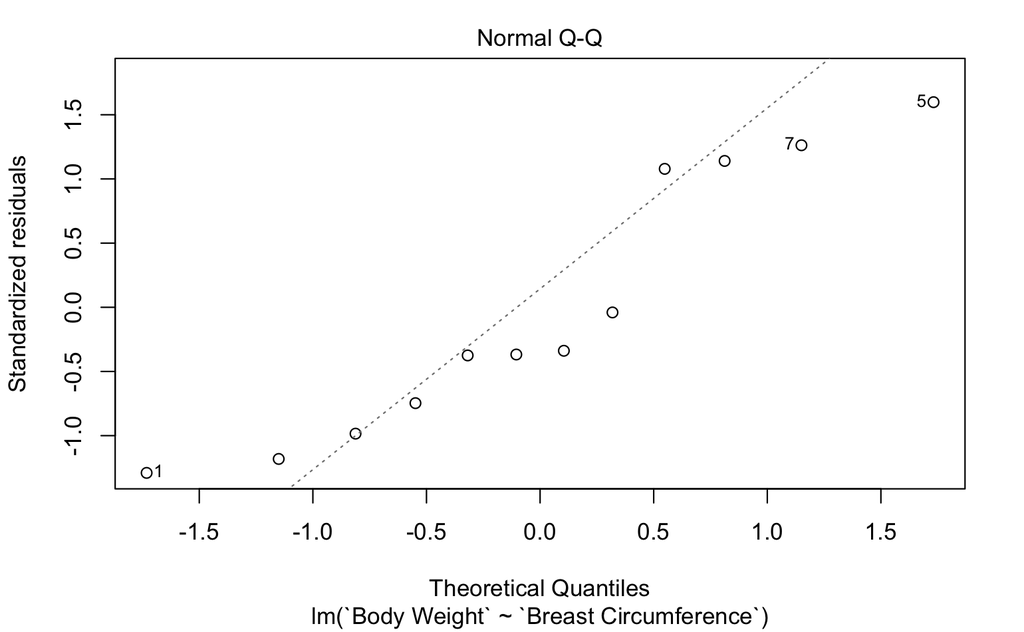

```r
plot(lm_rep_obs, 2)
```

## ANOVA

What does the ANOVA give us? First, we start with the single observation data

```r
s_bw_bc_reg_path <- file.path(here::here(), "docs", "data", "asm_bw_bc_reg.csv")
tbl_bw_bc_reg <- readr::read_csv(file = s_bw_bc_reg_path)
aov_bw_bc_reg <- aov(formula = `Body Weight` ~ `Breast Circumference`, data = tbl_bw_bc_reg)
summary(aov_bw_bc_reg)
```

```
                       Df Sum Sq Mean Sq F value   Pr(>F)
`Breast Circumference`  1   4581    4581   37.31 0.000287 ***
Residuals               8    982     123
---
Signif. codes:  0 ‘***’ 0.001 ‘**’ 0.01 ‘*’ 0.05 ‘.’ 0.1 ‘ ’ 1
```

The above information is also included in the summary output of the linear regression model.

```r
lm_bw_bc_reg <- lm(formula = `Body Weight` ~ `Breast Circumference`, data = tbl_bw_bc_reg)
summary(lm_bw_bc_reg)
```

```
Call:
lm(formula = `Body Weight` ~ `Breast Circumference`, data = tbl_bw_bc_reg)

Residuals:
     Min       1Q   Median       3Q      Max
-17.3941  -6.5525  -0.0673   9.3707  13.2594

Coefficients:
                        Estimate Std. Error t value Pr(>|t|)
(Intercept)            -1065.115    255.483  -4.169 0.003126 **
`Breast Circumference`     8.673      1.420   6.108 0.000287 ***
---
Signif. codes:  0 ‘***’ 0.001 ‘**’ 0.01 ‘*’ 0.05 ‘.’ 0.1 ‘ ’ 1

Residual standard error: 11.08 on 8 degrees of freedom
Multiple R-squared:  0.8234,    Adjusted R-squared:  0.8014
F-statistic: 37.31 on 1 and 8 DF,  p-value: 0.000287
```

```r
aov_rep_obs <- aov(formula = `Body Weight` ~ `Breast Circumference`, data = tbl_rep_obs)
summary(aov_rep_obs)
```

```
                       Df Sum Sq Mean Sq F value  Pr(>F)
`Breast Circumference`  1   8533    8533   276.1 1.3e-08 ***
Residuals              10    309      31
---
Signif. codes:  0 ‘***’ 0.001 ‘**’ 0.01 ‘*’ 0.05 ‘.’ 0.1 ‘ ’ 1
```

# Two Way Repeated Measures ANOVA

From https://youtu.be/eT_SLeXMOYE, we get

```r
s_bw_breed_rep_obs_path <- "https://charlotte-ngs.github.io/asmss2022/data/asm_bw_breed_rep_obs.csv"
tbl_rep_obs_breed <- readr::read_csv(file = s_bw_breed_rep_obs_path)
tbl_rep_obs_breed$Animal <- as.factor(tbl_rep_obs_breed$Animal)
tbl_rep_obs_breed$Breed <- as.factor(tbl_rep_obs_breed$Breed)
tbl_rep_obs_breed$Time <- as.factor(tbl_rep_obs_breed$Time)
tbl_rep_obs_breed
```

| Animal | Body Weight | Breed | Time |
| --- | --- | --- | --- |
| 2 | 463.0000 | Angus | first |
| 2 | 468.8940 | Angus | second |
| 2 | 467.8753 | Angus | third |
| 5 | 496.0000 | Simmental | first |
| 5 | 495.0033 | Simmental | second |
| 5 | 493.6563 | Simmental | third |
| 7 | 518.0000 | Limousin | first |
| 7 | 509.3221 | Limousin | second |
| 7 | 506.5958 | Limousin | third |
| 10 | 541.0000 | Limousin | first |

[output cut: 2 more lines]

Run the repeated measures ANOVA

```r
aov_bw_breed_rep <- aov(`Body Weight` ~ Breed + Time + Error(Animal/Time), data = tbl_rep_obs_breed)
summary(aov_bw_breed_rep)
```

```
Error: Animal
          Df Sum Sq Mean Sq F value Pr(>F)
Breed      2   7356    3678   2.826  0.388
Residuals  1   1302    1302

Error: Animal:Time
          Df Sum Sq Mean Sq F value Pr(>F)
Time       2  50.33   25.17   1.131  0.383
Residuals  6 133.51   22.25
```

Use just the one-way repeated measures ANOVA

```r
aov_bw_rep <- aov(`Body Weight` ~ Time + Error(Animal/Time), data = tbl_rep_obs_breed)
summary(aov_bw_rep)
```

```
Error: Animal
          Df Sum Sq Mean Sq F value Pr(>F)
Residuals  3   8658    2886

Error: Animal:Time
          Df Sum Sq Mean Sq F value Pr(>F)
Time       2  50.33   25.17   1.131  0.383
Residuals  6 133.51   22.25
```

```r
aov_bw_breed_rep <- aov(`Body Weight` ~ Breed + Error(Animal), data = tbl_rep_obs_breed)
summary(aov_bw_breed_rep)
```

```
Error: Animal
          Df Sum Sq Mean Sq F value Pr(>F)
Breed      2   7356    3678   2.826  0.388
Residuals  1   1302    1302

Error: Within
          Df Sum Sq Mean Sq F value Pr(>F)
Residuals  8  183.8   22.98
```

Reproduce the computations

## One way repeated measurements

```r
aov_bw_rep <- aov(`Body Weight` ~ Error(Animal), data = tbl_rep_obs_breed)
summary(aov_bw_rep)
```

```
Error: Animal
          Df Sum Sq Mean Sq F value Pr(>F)
Residuals  3   8658    2886

Error: Within
          Df Sum Sq Mean Sq F value Pr(>F)
Residuals  8  183.8   22.98
```

Boxplot

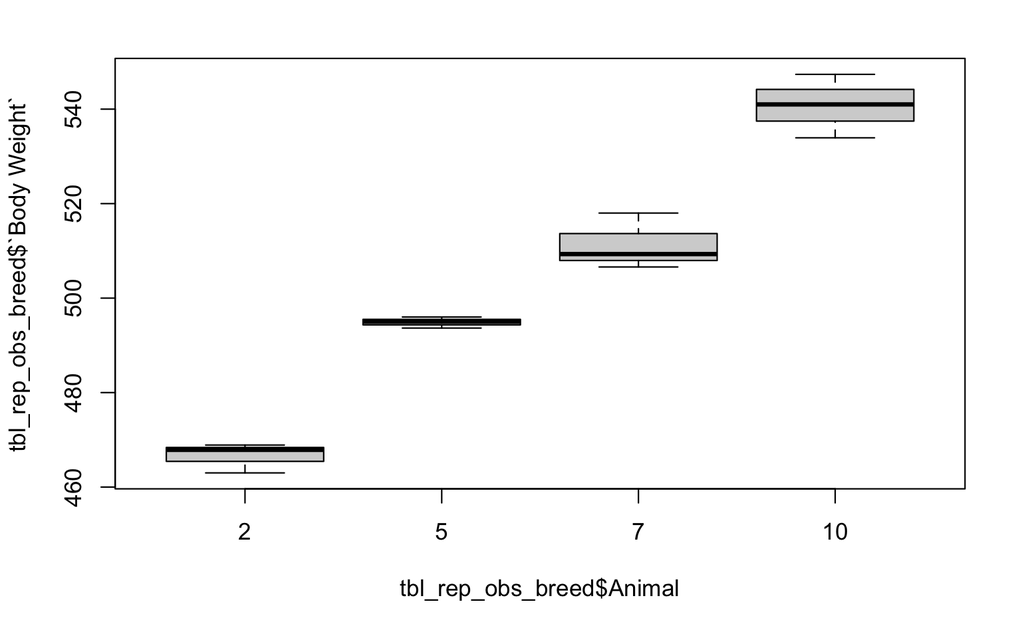

```r
boxplot(tbl_rep_obs_breed$`Body Weight` ~ tbl_rep_obs_breed$Animal)
```

Reproduce the computations

```r
(n_mean_bw_total <- mean(tbl_rep_obs_breed$`Body Weight`))
```

```
[1] 503.3864
```

```r
(n_ssq_total <- sum((tbl_rep_obs_breed$`Body Weight`-n_mean_bw_total)^2))
```

```
[1] 8841.804
```

```r
(n_mean_bw_2 <- mean(tbl_rep_obs_breed$`Body Weight`[tbl_rep_obs_breed$Animal == 2]))
```

```
[1] 466.5898
```

```r
(n_mean_bw_5 <- mean(tbl_rep_obs_breed$`Body Weight`[tbl_rep_obs_breed$Animal == 5]))
```

```
[1] 494.8866
```

```r
(n_mean_bw_7 <- mean(tbl_rep_obs_breed$`Body Weight`[tbl_rep_obs_breed$Animal == 7]))
```

```
[1] 511.3059
```

```r
(n_mean_bw_10 <- mean(tbl_rep_obs_breed$`Body Weight`[tbl_rep_obs_breed$Animal == 10]))
```

```
[1] 540.7632
```

```r
(n_ssq_res <- sum((tbl_rep_obs_breed$`Body Weight`[tbl_rep_obs_breed$Animal == 2] - n_mean_bw_2)^2 +
                      (tbl_rep_obs_breed$`Body Weight`[tbl_rep_obs_breed$Animal == 5] - n_mean_bw_5)^2 +
                      (tbl_rep_obs_breed$`Body Weight`[tbl_rep_obs_breed$Animal == 7] - n_mean_bw_7)^2 +
                      (tbl_rep_obs_breed$`Body Weight`[tbl_rep_obs_breed$Animal == 10] - n_mean_bw_10)^2))
```

```
[1] 183.8415
```

```r
(n_ssq_animal <- n_nr_rep * sum((n_mean_bw_2 - n_mean_bw_total)^2 +
                      (n_mean_bw_5 - n_mean_bw_total)^2 +
                      (n_mean_bw_7  - n_mean_bw_total)^2 +
                      (n_mean_bw_10  - n_mean_bw_total)^2))
```

```
[1] 8657.962
```

Going back to two-way and do the computations for the breed

```r
(n_mean_bw_an <- mean(tbl_rep_obs_breed$`Body Weight`[tbl_rep_obs_breed$Breed == "Angus"]))
```

```
[1] 466.5898
```

```r
(n_mean_bw_si <- mean(tbl_rep_obs_breed$`Body Weight`[tbl_rep_obs_breed$Breed == "Simmental"]))
```

```
[1] 494.8866
```

```r
(n_mean_bw_li <- mean(tbl_rep_obs_breed$`Body Weight`[tbl_rep_obs_breed$Breed == "Limousin"]))
```

```
[1] 526.0346
```

```r
(n_nr_an <- length(tbl_rep_obs_breed$`Body Weight`[tbl_rep_obs_breed$Breed == "Angus"]))
```

```
[1] 3
```

```r
(n_nr_si <- length(tbl_rep_obs_breed$`Body Weight`[tbl_rep_obs_breed$Breed == "Simmental"]))
```

```
[1] 3
```

```r
(n_nr_li <- length(tbl_rep_obs_breed$`Body Weight`[tbl_rep_obs_breed$Breed == "Limousin"]))
```

```
[1] 6
```

```r
(n_ssq_breed <- sum(n_nr_an * (n_mean_bw_an - n_mean_bw_total)^2 +
                    n_nr_si * (n_mean_bw_si - n_mean_bw_total)^2 +
                    n_nr_li * (n_mean_bw_li - n_mean_bw_total)^2 ))
```

```
[1] 7356.364
```

```r
(n_ssq_breed_res <- sum((tbl_rep_obs_breed$`Body Weight`[tbl_rep_obs_breed$Breed == "Angus"]-n_mean_bw_an)^2 +
                         (tbl_rep_obs_breed$`Body Weight`[tbl_rep_obs_breed$Breed == "Simmental"] - n_mean_bw_si)^2 +
                         (tbl_rep_obs_breed$`Body Weight`[tbl_rep_obs_breed$Breed == "Limousin"] - n_mean_bw_li)^2))
```

```
[1] 1508.055
```